# Лабораторная работа №2

Цопанов Данил

01/05/2020

# Исследование сетевых параметров публичных DNS серверов

## Цель работы:

Проанализировать сетевые параметры публичных DNS серверов, сделать мотивированный вывод о предпочтительных серверах.

### Исследуемые провайдеры DNS:

1. Google Public DNS
2. Cloudflare DNS
3. OpenDNS
4. DNS провайдера

## Исходные данные:

### Конфигурация аппаратного обеспечения и общесистемного ПО:

Процессор: 4 × Intel® Core™ i5-3230M CPU @ 2.60GHz  
Память: 7,89 Гб ОЗУ  
ОС: Windows 10 x64

### Используемое ПО:

- Google Chrome 81.0.4044.122
- Rstudio IDE

### Используемые команды для командной строки:

- ping
- tracert

### Используемые интернет-ресурсы:

- Whois

## Содержание лабораторной работы:

### 1. Google Public DNS

Данный провайдер DNS имеет адрес 8.8.8.8  
Для начала проверим доступность этого адреса с помощью утилиты ping.  
PING - основная утилита командной строки Windows для проверки соединений в сетях на основе TCP/IP. Команда PING с помощью отправки сообщений с эхо-запросом по протоколу ICMP проверяет соединение на уровне протокола IP с другим устройством, поддерживающим TCP/IP. После каждой передачи выводится соответствующее сообщение с эхо-ответом.

```r
system("ping 8.8.8.8 ", intern = TRUE)
```

```
##  [1] ""
##  [2] "Обмен пакетами с 8.8.8.8 по с 32 байтами данных:"
##  [3] "Ответ от 8.8.8.8: число байт=32 время=17мс TTL=46"
##  [4] "Ответ от 8.8.8.8: число байт=32 время=17мс TTL=46"
##  [5] "Ответ от 8.8.8.8: число байт=32 время=17мс TTL=46"
##  [6] "Ответ от 8.8.8.8: число байт=32 время=16мс TTL=46"
##  [7] ""
##  [8] "Статистика Ping для 8.8.8.8:"
##  [9] "    Пакетов: отправлено = 4, получено = 4, потеряно = 0"
## [10] "    (0% потерь)"
## [11] "Приблизительное время приема-передачи в мс:"
## [12] "    Минимальное = 16мсек, Максимальное = 17 мсек, Среднее = 16 мсек"
```

Адрес оказался доступным, поэтому можно сделать трассировку маршрута и узнать, через какие узлы проходит пакет до конечного адреса  
В командной строке Windows можно сделать это с помощью утилиты tracert:

```r
system("tracert 8.8.8.8", intern = TRUE)
```

```
##  [1] ""
##  [2] "Трассировка маршрута к dns.google [8.8.8.8]"
##  [3] "с максимальным числом прыжков 30:"
##  [4] ""
##  [5] "  1     2 ms    <1 мс    <1 мс  192.168.0.1 "
##  [6] "  2     5 ms     2 ms     2 ms  broadband-46-188-55-1.2com.net [46.188.55.1] "
##  [7] "  3     5 ms     6 ms     3 ms  juni-vl-431-m10.setel.ru [80.253.16.29] "
##  [8] "  4     2 ms     2 ms     2 ms  80.253.16.82 "
##  [9] "  5     3 ms     2 ms     3 ms  80.253.16.81 "
## [10] "  6     4 ms     4 ms     4 ms  108.170.250.129 "
## [11] "  7     5 ms     3 ms     4 ms  108.170.250.146 "
## [12] "  8    18 ms    17 ms    17 ms  216.239.50.2 "
## [13] "  9    20 ms    24 ms    20 ms  108.170.232.251 "
## [14] " 10    20 ms    17 ms    19 ms  172.253.51.243 "
## [15] " 11     *        *        *     Превышен интервал ожидания для запроса."
## [16] " 12     *        *        *     Превышен интервал ожидания для запроса."
## [17] " 13     *        *        *     Превышен интервал ожидания для запроса."
## [18] " 14     *        *        *     Превышен интервал ожидания для запроса."
## [19] " 15     *        *        *     Превышен интервал ожидания для запроса."
## [20] " 16     *        *        *     Превышен интервал ожидания для запроса."
## [21] " 17     *        *        *     Превышен интервал ожидания для запроса."
## [22] " 18     *        *        *     Превышен интервал ожидания для запроса."
## [23] " 19     *        *        *     Превышен интервал ожидания для запроса."
## [24] " 20    18 ms    20 ms    25 ms  dns.google [8.8.8.8] "
## [25] ""
## [26] "Трассировка завершена."
```

Каждая строка вывода команды tracert пронумерована, каждая такая строка называется шагом, хопом или прыжком. По умолчанию tracert в Windows отправляет три запроса на каждый хоп и получает от этого хопа ответы, если ответ не получен, то в первых трех столбцах мы видим символ «*», если ответ получен, то в первых трех столбцах указывается время прохождения пакета, а в следующем столбце Windows дает нам подсказку о причинах, по которым удаленный узел нам не ответил или его адрес, если узел ответил.

| № | Среднее t | Узлы маршрута | Организация | Город |
| --- | --- | --- | --- | --- |
| 1 | 1 ms | 192.168.0.1 | Домашний роутер | Krasnogorsk |
| 2 | 3 ms | 46.188.55.1 | 2COM Co ltd. | Moscow |
| 3 | 5 ms | 80.253.16.29 | DISKOM-NET | Moscow |
| 4 | 2 ms | 80.253.16.82 | OSTOJENKA-ARHITEKTURNOE-BYURO | Moscow |
| 5 | 3 ms | 80.253.16.81 | OSTOJENKA-ARHITEKTURNOE-BYURO | Moscow |
| 6 | 4 ms | 108.170.250.129 | Google LLC (GOGL) | Mountain View |
| 7 | 4 ms | 108.170.250.146 | Google LLC (GOGL) | Mountain View |
| 8 | 17 ms | 216.239.50.2 | Google LLC (GOGL) | Mountain View |
| 9 | 21 ms | 108.170.232.251 | Google LLC (GOGL) | Mountain View |
| 10 | 19 ms | 172.253.51.243 | Google LLC (GOGL) | Mountain View |
| 20 | 21 ms | dns.google [8.8.8.8] | Level 3 Parent, LLC (LPL-141) | Monroe |

### 2. Cloudflare DNS

Данный провайдер DNS имеет адрес 1.1.1.1  
Для начала проверим доступность этого адреса с помощью утилиты ping.  
PING - основная утилита командной строки Windows для проверки соединений в сетях на основе TCP/IP. Команда PING с помощью отправки сообщений с эхо-запросом по протоколу ICMP проверяет соединение на уровне протокола IP с другим устройством, поддерживающим TCP/IP. После каждой передачи выводится соответствующее сообщение с эхо-ответом.

```r
system("ping 1.1.1.1", intern = TRUE)
```

```
##  [1] ""
##  [2] "Обмен пакетами с 1.1.1.1 по с 32 байтами данных:"
##  [3] "Ответ от 1.1.1.1: число байт=32 время=4мс TTL=59"
##  [4] "Ответ от 1.1.1.1: число байт=32 время=4мс TTL=59"
##  [5] "Ответ от 1.1.1.1: число байт=32 время=4мс TTL=59"
##  [6] "Ответ от 1.1.1.1: число байт=32 время=6мс TTL=59"
##  [7] ""
##  [8] "Статистика Ping для 1.1.1.1:"
##  [9] "    Пакетов: отправлено = 4, получено = 4, потеряно = 0"
## [10] "    (0% потерь)"
## [11] "Приблизительное время приема-передачи в мс:"
## [12] "    Минимальное = 4мсек, Максимальное = 6 мсек, Среднее = 4 мсек"
```

Адрес оказался доступным, поэтому можно сделать трассировку маршрута и узнать, через какие узлы проходит пакет до конечного адреса.  
В командной строке Windows можно сделать это с помощью утилиты tracert:

```r
system("tracert 1.1.1.1", intern = TRUE)
```

```
##  [1] ""
##  [2] "Трассировка маршрута к one.one.one.one [1.1.1.1]"
##  [3] "с максимальным числом прыжков 30:"
##  [4] ""
##  [5] "  1     1 ms    <1 мс     5 ms  192.168.0.1 "
##  [6] "  2     3 ms     7 ms     2 ms  broadband-46-188-55-1.2com.net [46.188.55.1] "
##  [7] "  3     3 ms     7 ms     4 ms  juni-vl-431-m10.setel.ru [80.253.16.29] "
##  [8] "  4     2 ms     3 ms     2 ms  80.64.108.155.rascom.as20764.net [80.64.108.155] "
##  [9] "  5     4 ms     5 ms     3 ms  msk-m9-cr3.ae2223-0.rascom.as20764.net [80.64.108.154] "
## [10] "  6     5 ms     3 ms     3 ms  msk-m9-cr2.be40.rascom.as20764.net [80.64.96.244] "
## [11] "  7     5 ms    12 ms     6 ms  172.68.8.252 "
## [12] "  8     4 ms     6 ms     3 ms  one.one.one.one [1.1.1.1] "
## [13] ""
## [14] "Трассировка завершена."
```

Каждая строка вывода команды tracert пронумерована, каждая такая строка называется шагом, хопом или прыжком. По умолчанию tracert в Windows отправляет три запроса на каждый хоп и получает от этого хопа ответы, если ответ не получен, то в первых трех столбцах мы видим символ «*», если ответ получен, то в первых трех столбцах указывается время прохождения пакета, а в следующем столбце Windows дает нам подсказку о причинах, по которым удаленный узел нам не ответил или его адрес, если узел ответил.

| № | Среднее t | Узлы маршрута | Организация | Город |
| --- | --- | --- | --- | --- |
| 1 | 2 ms | 192.168.0.1 | Домашний роутер | Krasnogorsk |
| 2 | 4 ms | 46.188.55.1 | 2COM Co ltd. | Moscow |
| 3 | 5 ms | 80.253.16.29 | DISKOM | Moscow |
| 4 | 2 ms | 80.64.108.155 | CJSC Rascom | St.Petersburg |
| 5 | 4 ms | 80.64.108.154 | CJSC Rascom | St.Petersburg |
| 6 | 4 ms | 80.64.96.244 | CJSC Rascom | St.Petersburg |
| 7 | 8 ms | 172.68.8.252 | Cloudflare, Inc. | San Francisco |
| 8 | 4 ms | 1.1.1.1 | APNIC Research and Development | South Brisbane |

### 3. OpenDNS

Данный провайдер DNS имеет адрес 208.67.222.222  
Для начала проверим доступность этого адреса с помощью утилиты ping.  
PING - основная утилита командной строки Windows для проверки соединений в сетях на основе TCP/IP. Команда PING с помощью отправки сообщений с эхо-запросом по протоколу ICMP проверяет соединение на уровне протокола IP с другим устройством, поддерживающим TCP/IP. После каждой передачи выводится соответствующее сообщение с эхо-ответом.

```r
system("ping 208.67.222.222", intern = TRUE)
```

```
##  [1] ""
##  [2] "Обмен пакетами с 208.67.222.222 по с 32 байтами данных:"
##  [3] "Ответ от 208.67.222.222: число байт=32 время=48мс TTL=56"
##  [4] "Ответ от 208.67.222.222: число байт=32 время=49мс TTL=56"
##  [5] "Ответ от 208.67.222.222: число байт=32 время=54мс TTL=56"
##  [6] "Ответ от 208.67.222.222: число байт=32 время=51мс TTL=56"
##  [7] ""
##  [8] "Статистика Ping для 208.67.222.222:"
##  [9] "    Пакетов: отправлено = 4, получено = 4, потеряно = 0"
## [10] "    (0% потерь)"
## [11] "Приблизительное время приема-передачи в мс:"
## [12] "    Минимальное = 48мсек, Максимальное = 54 мсек, Среднее = 50 мсек"
```

Адрес оказался доступным, поэтому можно сделать трассировку маршрута и узнать, через какие узлы проходит пакет до конечного адреса.  
В командной строке Windows можно сделать это с помощью утилиты tracert:

```r
system("tracert 208.67.222.222", intern = TRUE)
```

```
##  [1] ""
##  [2] "Трассировка маршрута к resolver1.opendns.com [208.67.222.222]"
##  [3] "с максимальным числом прыжков 30:"
##  [4] ""
##  [5] "  1     6 ms    <1 мс     1 ms  192.168.0.1 "
##  [6] "  2     2 ms     2 ms     2 ms  broadband-46-188-55-1.2com.net [46.188.55.1] "
##  [7] "  3     4 ms    12 ms     2 ms  juni-vl-431-m10.setel.ru [80.253.16.29] "
##  [8] "  4     8 ms     4 ms     9 ms  92.50.240.133 "
##  [9] "  5    27 ms    28 ms    27 ms  ae40.stkm-cr4.intl.ip.rostelecom.ru [217.107.67.31] "
## [10] "  6    24 ms    25 ms    27 ms  ae1-500.cr1-stk3.ip4.gtt.net [77.67.90.96] "
## [11] "  7    51 ms    51 ms    51 ms  ae13.cr5-ams1.ip4.gtt.net [213.200.117.202] "
## [12] "  8    63 ms    63 ms    64 ms  opendns-gw.ip4.gtt.net [77.67.66.70] "
## [13] "  9    48 ms    48 ms    50 ms  resolver1.opendns.com [208.67.222.222] "
## [14] ""
## [15] "Трассировка завершена."
```

Каждая строка вывода команды tracert пронумерована, каждая такая строка называется шагом, хопом или прыжком. По умолчанию tracert в Windows отправляет три запроса на каждый хоп и получает от этого хопа ответы, если ответ не получен, то в первых трех столбцах мы видим символ «*», если ответ получен, то в первых трех столбцах указывается время прохождения пакета, а в следующем столбце Windows дает нам подсказку о причинах, по которым удаленный узел нам не ответил или его адрес, если узел ответил.

| № | Среднее t | Узлы маршрута | Организация | Город |
| --- | --- | --- | --- | --- |
| 1 | 3 ms | 192.168.0.1 | Домашний роутер | Krasnogorsk |
| 2 | 2 ms | 46.188.55.1 | 2COM Co ltd. | Moscow |
| 3 | 6 ms | 80.253.16.29 | DISKOM | Moscow |
| 4 | 7 ms | 92.50.240.133 | PJSC Rostelecom | Moscow |
| 5 | 27 ms | 217.107.67.31 | PJSC Rostelecom | Moscow |
| 6 | 25 ms | 77.67.90.96 | Tinet International Network | Neu-Isenburg |
| 7 | 51 ms | 213.200.117.202 | GTT | Neu-Isenburg |
| 8 | 64 ms | 77.67.66.70 | Tiscali International Network B.V. | Neu-Isenburg |
| 9 | 48 ms | 208.67.222.222 | OPENDNS-NET-1 | San Francisco |

### 4. DNS провайдера

Данный провайдер DNS имеет адрес 195.98.160.26  
Для начала проверим доступность этого адреса с помощью утилиты ping.  
PING - основная утилита командной строки Windows для проверки соединений в сетях на основе TCP/IP. Команда PING с помощью отправки сообщений с эхо-запросом по протоколу ICMP проверяет соединение на уровне протокола IP с другим устройством, поддерживающим TCP/IP. После каждой передачи выводится соответствующее сообщение с эхо-ответом.

```r
system("ping 195.98.160.26", intern = TRUE)
```

```
##  [1] ""
##  [2] "Обмен пакетами с 195.98.160.26 по с 32 байтами данных:"
##  [3] "Ответ от 195.98.160.26: число байт=32 время=4мс TTL=59"
##  [4] "Ответ от 195.98.160.26: число байт=32 время=5мс TTL=59"
##  [5] "Ответ от 195.98.160.26: число байт=32 время=4мс TTL=59"
##  [6] "Ответ от 195.98.160.26: число байт=32 время=6мс TTL=59"
##  [7] ""
##  [8] "Статистика Ping для 195.98.160.26:"
##  [9] "    Пакетов: отправлено = 4, получено = 4, потеряно = 0"
## [10] "    (0% потерь)"
## [11] "Приблизительное время приема-передачи в мс:"
## [12] "    Минимальное = 4мсек, Максимальное = 6 мсек, Среднее = 4 мсек"
```

Адрес оказался доступным, поэтому можно сделать трассировку маршрута и узнать, через какие узлы проходит пакет до конечного адреса.  
В командной строке Windows можно сделать это с помощью утилиты tracert:

```r
system("tracert 195.98.160.26", intern = TRUE)
```

```
##  [1] ""
##  [2] "Трассировка маршрута к dns1.2com.net [195.98.160.26]"
##  [3] "с максимальным числом прыжков 30:"
##  [4] ""
##  [5] "  1     1 ms     3 ms    <1 мс  192.168.0.1 "
##  [6] "  2     3 ms     5 ms     5 ms  broadband-46-188-55-1.2com.net [46.188.55.1] "
##  [7] "  3     6 ms     1 ms     2 ms  172.31.246.205 "
##  [8] "  4     3 ms     2 ms     2 ms  172.31.251.224 "
##  [9] "  5     2 ms     5 ms     4 ms  juni-vl-924-ecmp-m10.setel.ru [80.253.16.113] "
## [10] "  6     3 ms     7 ms     5 ms  dns1.2com.net [195.98.160.26] "
## [11] ""
## [12] "Трассировка завершена."
```

Каждая строка вывода команды tracert пронумерована, каждая такая строка называется шагом, хопом или прыжком. По умолчанию tracert в Windows отправляет три запроса на каждый хоп и получает от этого хопа ответы, если ответ не получен, то в первых трех столбцах мы видим символ «*», если ответ получен, то в первых трех столбцах указывается время прохождения пакета, а в следующем столбце Windows дает нам подсказку о причинах, по которым удаленный узел нам не ответил или его адрес, если узел ответил.

| № | Среднее t | Узлы маршрута | Организация | Город |
| --- | --- | --- | --- | --- |
| 1 | 2 ms | 192.168.0.1 | Домашний роутер | Krasnogorsk |
| 2 | 4 ms | 46.188.55.1 | 2COM Co ltd. | Moscow |
| 3 | 3 ms | 172.31.246.205 | Internet Assigned Numbers Authority (IANA) | Los Angeles |
| 4 | 2 ms | 172.31.251.224 | Internet Assigned Numbers Authority (IANA) | Los Angeles |
| 5 | 4 ms | 80.253.16.113 | NACIONALNOE-BYURO-KREDITNIH-ISTORIY | Moscow |
| 6 | 5 ms | 195.98.160.26 | 2COM Co ltd. | Moscow |

## Оценка результата:

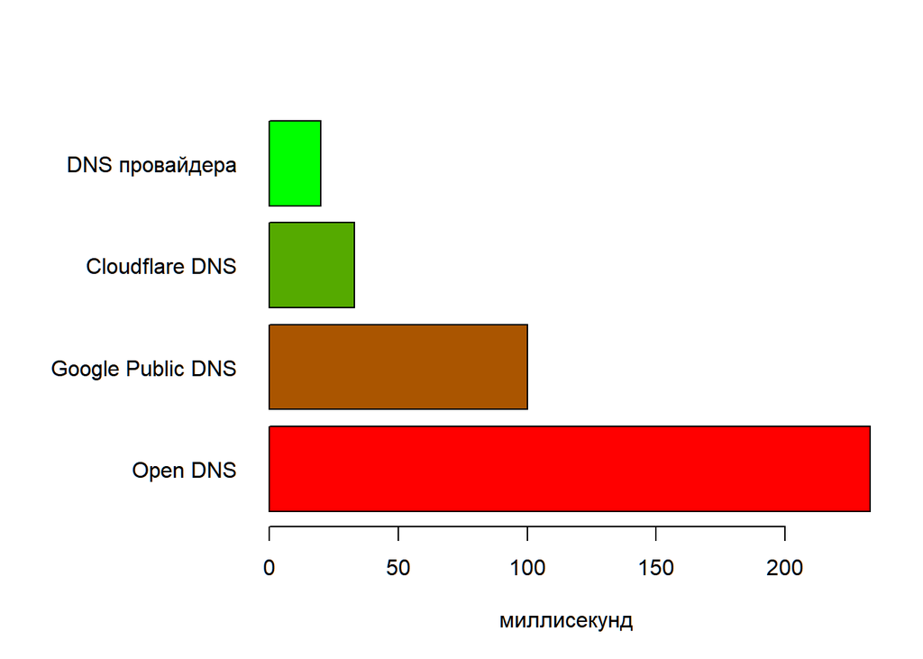

```r
time <- c(233, 100, 33, 20)
name <- c("Open DNS", "Google Public DNS",   "Cloudflare DNS", "DNS провайдера")
DNS <- data.frame(Name= name, Time = time)
palet=colorRampPalette(c("red","green"))
colors=palet(4)
par(mar = c(5, 10, 4, 2))
barplot(DNS$Time,
        names.arg = DNS$Name,
        horiz=TRUE,
        las = 1,
        col = colors,
        xlab = "миллисекунд")
```